[OHI Science](http://ohi-science.org) | [Citation policy](http://ohi-science.org/citation-policy/)

# OHI-Northeast: Plastic Pollution

Compiled on Fri Apr 21 10:23:45 2017 by afflerbach

# 1 Summary

As of now this is copied from Casey’s BC trash prep.

We are going to do a regional bounding box and use the maximum value in that box as the reference point. I’ll play with a couple different boxes to look at sensitivity.

# 2 Data

```r
vs_files_all <- list.files(dir_data_vs, full.names = TRUE) %>%
  setNames(basename(.) %>% str_replace('.csv', ''))

# [1] "gridcell_areas"            "latitudes"                 "lebretonmodel_abundance"
# [4] "lebretonmodel_mass"        "longitudes"                "maximenkomodel_abundance"
# [7] "maximenkomodel_mass"       "vansebillemodel_abundance" "vansebillemodel_mass"

vs_files <- vs_files_all[c(3, 4, 6,7,9,10)] ### select just data layers for models

vs_rasts <- vector('list', length = length(vs_files)) %>%
  setNames(names(vs_files))

for (i in 1:length(vs_files)) { ### i = 1
  vs_file <- vs_files[i]
  vs_fn <- names(vs_files)[i]

  vs_matrix <- read_csv(vs_file, col_names = FALSE) %>%
    data.matrix() %>%
    .[2:181, 1:360]
    ### it appears that row 361 is glitchy; ditch it, and ditch +90 N row as well
  rownames(vs_matrix) <- c(90:-89)
  colnames(vs_matrix) <- c(0:359)

  vs_rast <- raster(vs_matrix)
  extent(vs_rast) <- c(0, 360, -90, 90)
  vs_rast <- rotate(vs_rast)
  crs(vs_rast) <- CRS('+init=epsg:4326')

  vs_rasts[[vs_fn]] <- vs_rast
}

vs_stack <- stack(vs_rasts)
```

## 2.1 Compare regional extents

Does the regional extent dramatically change the result of the trash layer? Here are 4 arbitrarily determined extents.

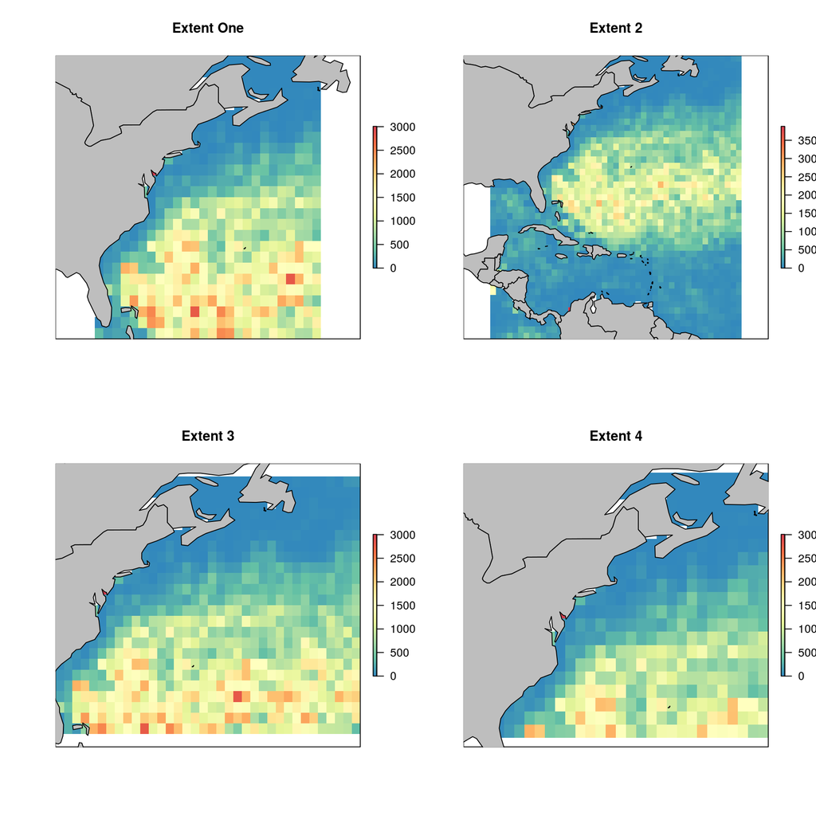

```r
### create North West Atlantic raster: north of Equator; using Law 2010 paper to determine boundaries (Figure 2): http://science.sciencemag.org/content/329/5996/1185.full

par(mfrow = c(2,2))
library(rworldmap)
world = getMap()

##Extent 1

ext_1 <- extent(c(-82,-56,24,50))
vs_mass_ext1 <- crop(vs_stack[['vansebillemodel_mass']],ext_1)
plot(vs_mass_ext1,col=cols,main = "Extent One",axes=F)
plot(world,col='gray',add=T)

## Extent 2
ext_2 <- extent(c(-90, -45, 5, 50))
vs_mass_ext2 <- crop(vs_stack[['vansebillemodel_mass']], ext_2)
plot(vs_mass_ext2,col=cols, axes=F, main = "Extent 2")
plot(world,col='gray',add=T)

## Extent 3
ext_3 <- extent(c(-81,-45,26,50))
vs_mass_ext3 <- crop(vs_stack[['vansebillemodel_mass']],ext_3)
plot(vs_mass_ext3,col=cols, axes=F, main = "Extent 3")
plot(world,col='gray',add=T)

## Extent 4
ext_4 <- wgs_ext
vs_mass_ext4 <- crop(vs_stack[['vansebillemodel_mass']], wgs_ext)
plot(vs_mass_ext4, col=cols, axes=F, main = "Extent 4")
plot(world,col='gray',add=T)
```

```r
### Save the global Van Sebille mass map cropped to the North Atlantic for additional reference point options
# writeRaster(vs_mass_natl,
#             file.path('int/cw_trash_mass_vansebille_n_atl.tif'),
#             overwrite = TRUE)

invisible(dev.off())
```

## 2.2 Reference points

Get the maximum value from each extent. Then we can rescale the regional data according to the different values and see the effect.

```r
ext_list <- list(vs_mass_ext1,vs_mass_ext2,vs_mass_ext3,vs_mass_ext4)

lapply(ext_list,cellStats,stat='max')
```

```
## [[1]]
## [1] 3007
##
## [[2]]
## [1] 3881
##
## [[3]]
## [1] 3007
##
## [[4]]
## [1] 3007
```

The maximum across all these extents is either 3,007 which is located off New Jersey, or 3,881 (extent 2 - located off Colombia).

Let’s go with 3,007.

## 2.3 Rescale marine plastics pressure from zero to 1

The highest amount of trash in the region is located right off New York City (3,007 g/km<sup>2</sup>). This drives all other values down when a regional reference point is used, whether the data are first log transformed or not.

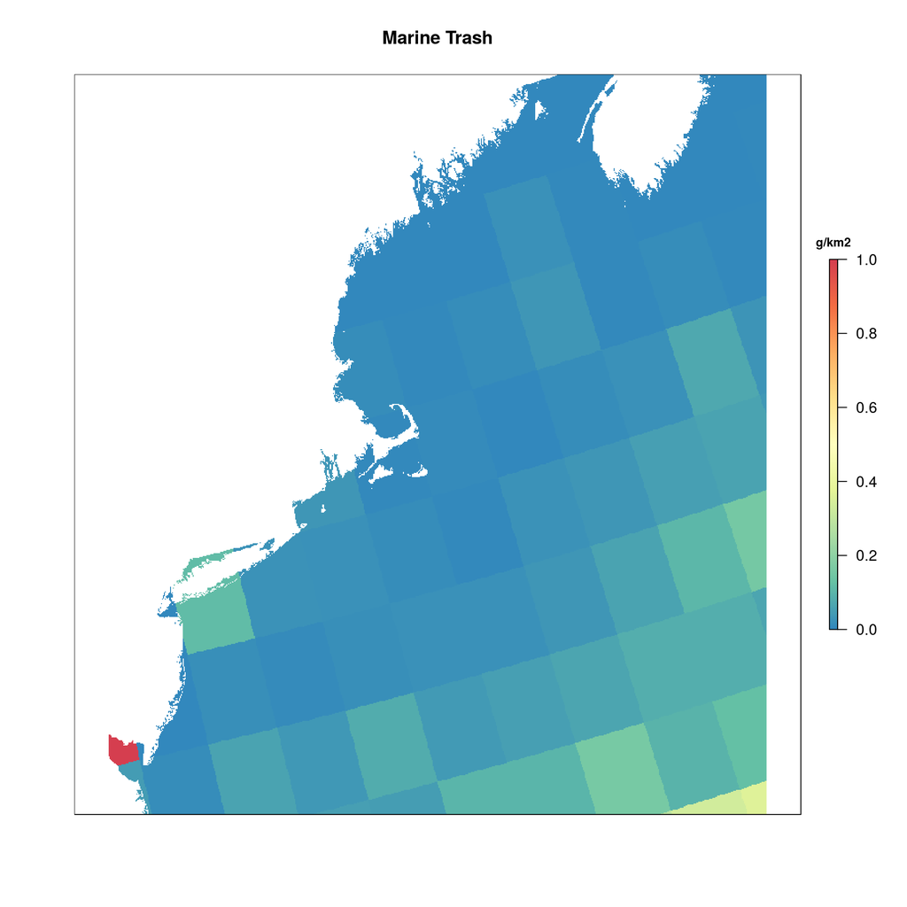

```r
trash_ne <- vs_mass_ext4
ref      <- cellStats(trash_ne,stat='max')

#rescale

trash_ne_resc <- trash_ne%>%
                   projectRaster(ocean_ne,method = 'ngb')%>%
                   mask(ocean_ne)%>%
                  calc(.,fun=function(x){ifelse(x>ref,1,x/ref)})

plot(trash_ne_resc,col=cols,main = "Marine Trash",axes=F,
     legend.args=list(text='g/km2', side=3, font=2, line=.5, cex=0.8))
```

# 3 Results

## 3.1 Region scores

By extracting the data for each of the 9 regions using the `zonal` function from the `raster` package we can get the mean score per region.

```r
# extract data for each region:
regions_stats <- zonal(trash_ne_resc,  zones, fun="mean", na.rm=TRUE, progress="text")%>%data.frame()
```

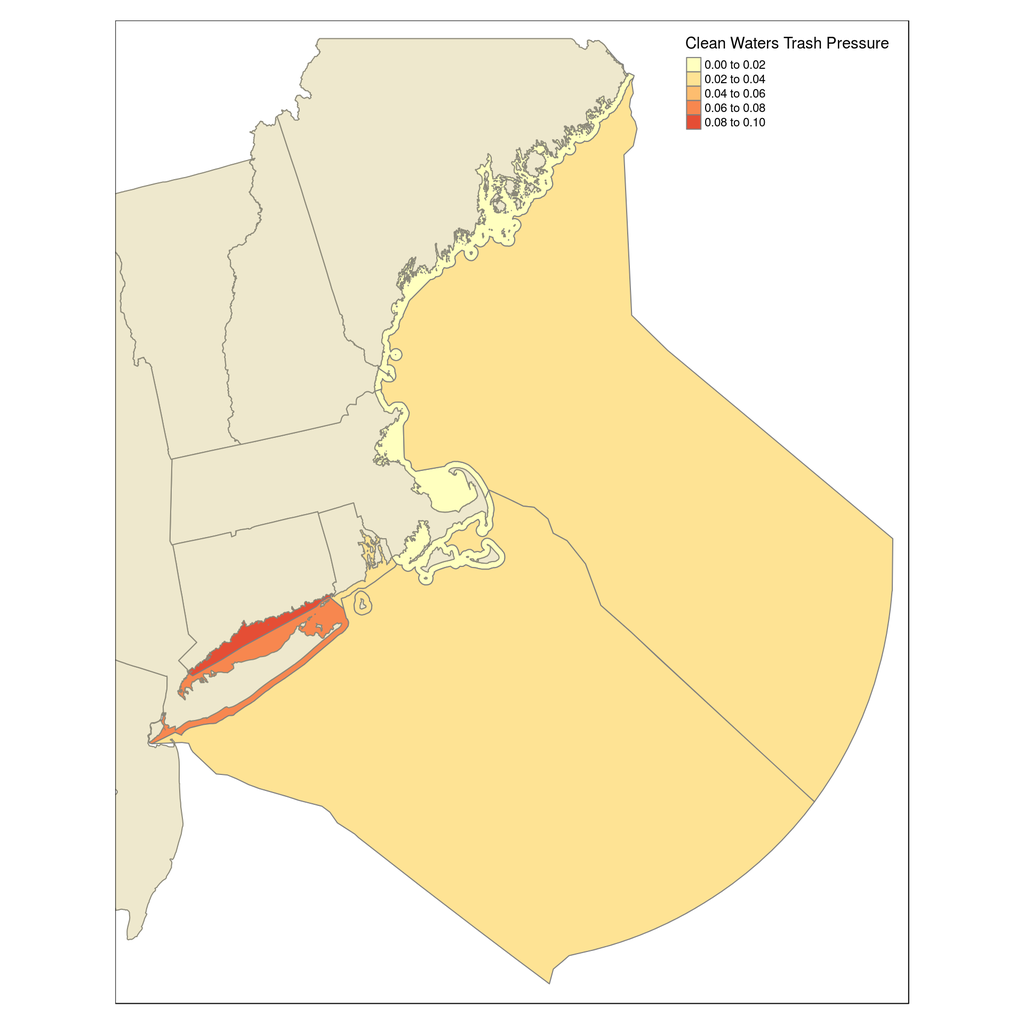

```r
data <- merge(rgn_data, regions_stats, all.y=TRUE, by.x="rgn_id", by.y="zone") %>%
          dplyr::select(-area_km2)%>%
  gather("year", "pressure_score",starts_with("mean"))

write.csv(data, "scores/trash.csv", row.names=FALSE)

#map_scores is a function to plot a tmap map of the scores
map_scores(data,'pressure_score',scale_label = "Clean Waters Trash Pressure", map_title = "",rev_col = T)
```